# Risk Factor Analysis

## Outcome Variable

**Outcome Variable:** co_occurence

## Predictor Variables

**Intervention Variable:** ever_swasted06

**Adjustment Set:**

unadjusted

## Stratifying Variables

The analysis was stratified on these variable(s):

- studyid
- country

## Data Summary

| studyid | country | ever_swasted06 | co_occurence | n_cell | n | outcome_variable |
| --- | --- | --- | --- | --- | --- | --- |
| CMC-V-BCS-2002 | INDIA | 0 | 0 | 287 | 366 | co_occurence |
| CMC-V-BCS-2002 | INDIA | 0 | 1 | 11 | 366 | co_occurence |
| CMC-V-BCS-2002 | INDIA | 1 | 0 | 57 | 366 | co_occurence |
| CMC-V-BCS-2002 | INDIA | 1 | 1 | 11 | 366 | co_occurence |
| CMIN | BANGLADESH | 0 | 0 | 203 | 237 | co_occurence |
| CMIN | BANGLADESH | 0 | 1 | 24 | 237 | co_occurence |
| CMIN | BANGLADESH | 1 | 0 | 8 | 237 | co_occurence |
| CMIN | BANGLADESH | 1 | 1 | 2 | 237 | co_occurence |
| COHORTS | GUATEMALA | 0 | 0 | 691 | 774 | co_occurence |
| COHORTS | GUATEMALA | 0 | 1 | 35 | 774 | co_occurence |
| COHORTS | GUATEMALA | 1 | 0 | 45 | 774 | co_occurence |
| COHORTS | GUATEMALA | 1 | 1 | 3 | 774 | co_occurence |
| COHORTS | PHILIPPINES | 0 | 0 | 2163 | 2487 | co_occurence |
| COHORTS | PHILIPPINES | 0 | 1 | 163 | 2487 | co_occurence |
| COHORTS | PHILIPPINES | 1 | 0 | 137 | 2487 | co_occurence |
| COHORTS | PHILIPPINES | 1 | 1 | 24 | 2487 | co_occurence |
| CONTENT | PERU | 0 | 0 | 199 | 200 | co_occurence |
| CONTENT | PERU | 0 | 1 | 0 | 200 | co_occurence |
| CONTENT | PERU | 1 | 0 | 1 | 200 | co_occurence |
| CONTENT | PERU | 1 | 1 | 0 | 200 | co_occurence |
| EE | PAKISTAN | 0 | 0 | 246 | 346 | co_occurence |
| EE | PAKISTAN | 0 | 1 | 64 | 346 | co_occurence |
| EE | PAKISTAN | 1 | 0 | 26 | 346 | co_occurence |
| EE | PAKISTAN | 1 | 1 | 10 | 346 | co_occurence |
| GMS-Nepal | NEPAL | 0 | 0 | 429 | 550 | co_occurence |
| GMS-Nepal | NEPAL | 0 | 1 | 50 | 550 | co_occurence |
| GMS-Nepal | NEPAL | 1 | 0 | 61 | 550 | co_occurence |
| GMS-Nepal | NEPAL | 1 | 1 | 10 | 550 | co_occurence |
| IRC | INDIA | 0 | 0 | 268 | 405 | co_occurence |
| IRC | INDIA | 0 | 1 | 15 | 405 | co_occurence |

[output cut: 78 more lines]

The following strata were considered:

- studyid: CMC-V-BCS-2002, country: INDIA
- studyid: CMIN, country: BANGLADESH
- studyid: COHORTS, country: GUATEMALA
- studyid: COHORTS, country: PHILIPPINES
- studyid: CONTENT, country: PERU
- studyid: EE, country: PAKISTAN
- studyid: GMS-Nepal, country: NEPAL
- studyid: IRC, country: INDIA
- studyid: JiVitA-4, country: BANGLADESH
- studyid: Keneba, country: GAMBIA
- studyid: LCNI-5, country: MALAWI
- studyid: MAL-ED, country: BANGLADESH
- studyid: MAL-ED, country: BRAZIL
- studyid: MAL-ED, country: INDIA
- studyid: MAL-ED, country: NEPAL
- studyid: MAL-ED, country: PERU
- studyid: MAL-ED, country: SOUTH AFRICA
- studyid: MAL-ED, country: TANZANIA, UNITED REPUBLIC OF
- studyid: NIH-Birth, country: BANGLADESH
- studyid: NIH-Crypto, country: BANGLADESH
- studyid: PROBIT, country: BELARUS
- studyid: PROVIDE, country: BANGLADESH
- studyid: ResPak, country: PAKISTAN
- studyid: SAS-CompFeed, country: INDIA
- studyid: SAS-FoodSuppl, country: INDIA
- studyid: TanzaniaChild2, country: TANZANIA, UNITED REPUBLIC OF
- studyid: ZVITAMBO, country: ZIMBABWE

### Dropped Strata

Some strata were dropped due to rare outcomes:

- studyid: CMIN, country: BANGLADESH
- studyid: COHORTS, country: GUATEMALA
- studyid: CONTENT, country: PERU
- studyid: LCNI-5, country: MALAWI
- studyid: MAL-ED, country: BANGLADESH
- studyid: MAL-ED, country: BRAZIL
- studyid: MAL-ED, country: NEPAL
- studyid: MAL-ED, country: PERU
- studyid: MAL-ED, country: SOUTH AFRICA
- studyid: MAL-ED, country: TANZANIA, UNITED REPUBLIC OF
- studyid: NIH-Crypto, country: BANGLADESH
- studyid: PROBIT, country: BELARUS
- studyid: PROVIDE, country: BANGLADESH
- studyid: ResPak, country: PAKISTAN
- studyid: TanzaniaChild2, country: TANZANIA, UNITED REPUBLIC OF

## Methods Detail

We’re interested in the causal parameters $E[Y_a]$ for all values of $a \in \mathcal{A}$. These parameters represent the mean outcome if, possibly contrary to fact, we intervened to set all units to have $A=a$. Under the randomization and positivity assumptions, these are identified by the statistical parameters $\psi_a=E_W[E_{Y|A,W}(Y|A=a,W)]$. In addition, we’re interested in the mean of $Y$, $E[Y]$ under no intervention (the observed mean). We will estimate these parameters by using SuperLearner to fit the relevant likelihood factors – $E_{Y|A,W}(Y|A=a,W)$ and $p(A=a|W)$, and then updating our likelihood fit using a joint TMLE.

For unadjusted analyses ($W=\{\}$), initial likelihoods were estimated using Lrnr_glm to estimate the simple $E(Y|A)$ and Lrnr_mean to estimate $p(A)$. For adjusted analyses, a small library containing Lrnr_glmnet, Lrnr_xgboost, and Lrnr_mean was used.

Having estimated these parameters, we will then use the delta method to estimate relative risks and attributable risks relative to a prespecified baseline level of $A$.

# Results Detail

## Results Plots

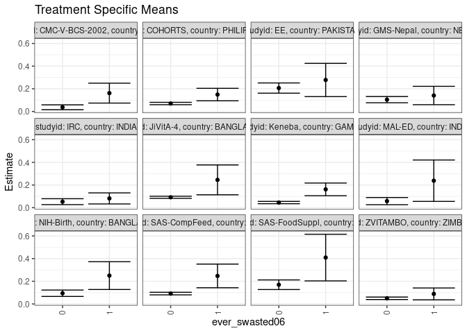

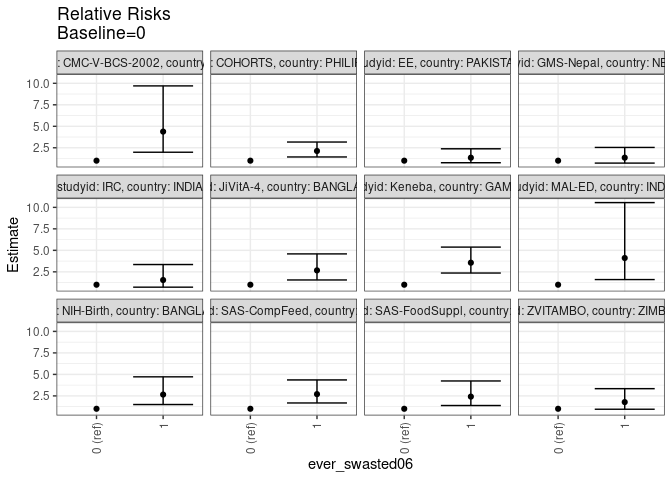

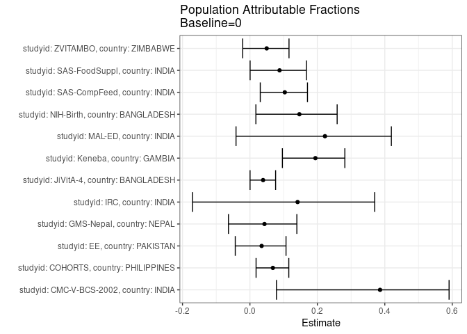

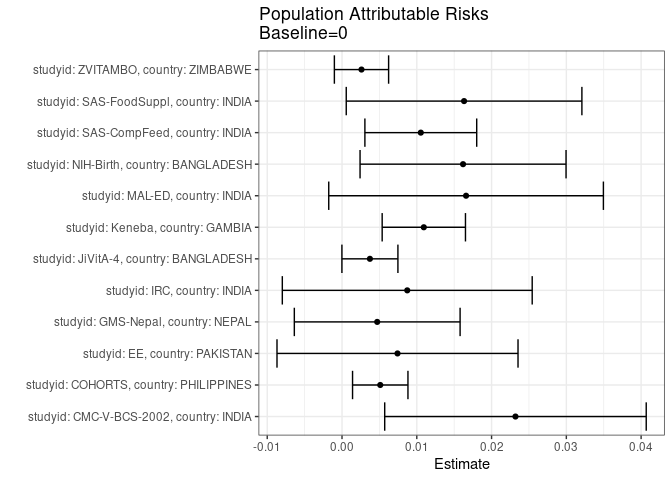

## Results Table

### Parameter: TSM

| studyid | country | intervention_level | baseline_level | estimate | ci_lower | ci_upper |
| --- | --- | --- | --- | --- | --- | --- |
| CMC-V-BCS-2002 | INDIA | 0 | NA | 0.0369128 | 0.0154762 | 0.0583493 |
| CMC-V-BCS-2002 | INDIA | 1 | NA | 0.1617647 | 0.0741226 | 0.2494068 |
| COHORTS | PHILIPPINES | 0 | NA | 0.0700774 | 0.0597011 | 0.0804537 |
| COHORTS | PHILIPPINES | 1 | NA | 0.1490683 | 0.0940430 | 0.2040936 |
| EE | PAKISTAN | 0 | NA | 0.2064516 | 0.1613293 | 0.2515740 |
| EE | PAKISTAN | 1 | NA | 0.2777778 | 0.1312535 | 0.4243020 |
| GMS-Nepal | NEPAL | 0 | NA | 0.1043841 | 0.0769776 | 0.1317906 |
| GMS-Nepal | NEPAL | 1 | NA | 0.1408451 | 0.0598571 | 0.2218331 |
| IRC | INDIA | 0 | NA | 0.0530035 | 0.0268688 | 0.0791383 |
| IRC | INDIA | 1 | NA | 0.0819672 | 0.0332307 | 0.1307037 |
| JiVitA-4 | BANGLADESH | 0 | NA | 0.0919176 | 0.0825271 | 0.1013081 |
| JiVitA-4 | BANGLADESH | 1 | NA | 0.2454545 | 0.1136645 | 0.3772446 |
| Keneba | GAMBIA | 0 | NA | 0.0453980 | 0.0352201 | 0.0555759 |
| Keneba | GAMBIA | 1 | NA | 0.1616766 | 0.1058243 | 0.2175290 |
| MAL-ED | INDIA | 0 | NA | 0.0579710 | 0.0260663 | 0.0898757 |
| MAL-ED | INDIA | 1 | NA | 0.2380952 | 0.0555298 | 0.4206607 |
| NIH-Birth | BANGLADESH | 0 | NA | 0.0942029 | 0.0660342 | 0.1223715 |
| NIH-Birth | BANGLADESH | 1 | NA | 0.2500000 | 0.1273695 | 0.3726305 |
| SAS-CompFeed | INDIA | 0 | NA | 0.0913749 | 0.0799866 | 0.1027631 |
| SAS-CompFeed | INDIA | 1 | NA | 0.2470588 | 0.1425705 | 0.3515471 |
| SAS-FoodSuppl | INDIA | 0 | NA | 0.1694352 | 0.1269902 | 0.2118802 |
| SAS-FoodSuppl | INDIA | 1 | NA | 0.4090909 | 0.2033217 | 0.6148601 |
| ZVITAMBO | ZIMBABWE | 0 | NA | 0.0497766 | 0.0390053 | 0.0605480 |
| ZVITAMBO | ZIMBABWE | 1 | NA | 0.0884956 | 0.0361140 | 0.1408771 |

### Parameter: E(Y)

| studyid | country | intervention_level | baseline_level | estimate | ci_lower | ci_upper |
| --- | --- | --- | --- | --- | --- | --- |
| CMC-V-BCS-2002 | INDIA | NA | NA | 0.0601093 | 0.0357249 | 0.0844936 |
| COHORTS | PHILIPPINES | NA | NA | 0.0751910 | 0.0648251 | 0.0855569 |
| EE | PAKISTAN | NA | NA | 0.2138728 | 0.1706052 | 0.2571404 |
| GMS-Nepal | NEPAL | NA | NA | 0.1090909 | 0.0830130 | 0.1351688 |
| IRC | INDIA | NA | NA | 0.0617284 | 0.0382610 | 0.0851958 |
| JiVitA-4 | BANGLADESH | NA | NA | 0.0956483 | 0.0855904 | 0.1057063 |
| Keneba | GAMBIA | NA | NA | 0.0563380 | 0.0456085 | 0.0670675 |
| MAL-ED | INDIA | NA | NA | 0.0745614 | 0.0403897 | 0.1087331 |
| NIH-Birth | BANGLADESH | NA | NA | 0.1103896 | 0.0817833 | 0.1389959 |
| SAS-CompFeed | INDIA | NA | NA | 0.1019108 | 0.0902026 | 0.1136190 |
| SAS-FoodSuppl | INDIA | NA | NA | 0.1857585 | 0.1432798 | 0.2282372 |
| ZVITAMBO | ZIMBABWE | NA | NA | 0.0523810 | 0.0417242 | 0.0630377 |

### Parameter: RR

| studyid | country | intervention_level | baseline_level | estimate | ci_lower | ci_upper |
| --- | --- | --- | --- | --- | --- | --- |
| CMC-V-BCS-2002 | INDIA | 0 | 0 | 1.000000 | 1.0000000 | 1.000000 |
| CMC-V-BCS-2002 | INDIA | 1 | 0 | 4.382353 | 1.9805297 | 9.696909 |
| COHORTS | PHILIPPINES | 0 | 0 | 1.000000 | 1.0000000 | 1.000000 |
| COHORTS | PHILIPPINES | 1 | 0 | 2.127196 | 1.4291587 | 3.166172 |
| EE | PAKISTAN | 0 | 0 | 1.000000 | 1.0000000 | 1.000000 |
| EE | PAKISTAN | 1 | 0 | 1.345486 | 0.7601655 | 2.381499 |
| GMS-Nepal | NEPAL | 0 | 0 | 1.000000 | 1.0000000 | 1.000000 |
| GMS-Nepal | NEPAL | 1 | 0 | 1.349296 | 0.7171014 | 2.538831 |
| IRC | INDIA | 0 | 0 | 1.000000 | 1.0000000 | 1.000000 |
| IRC | INDIA | 1 | 0 | 1.546448 | 0.7142847 | 3.348107 |
| JiVitA-4 | BANGLADESH | 0 | 0 | 1.000000 | 1.0000000 | 1.000000 |
| JiVitA-4 | BANGLADESH | 1 | 0 | 2.670376 | 1.5550701 | 4.585587 |
| Keneba | GAMBIA | 0 | 0 | 1.000000 | 1.0000000 | 1.000000 |
| Keneba | GAMBIA | 1 | 0 | 3.561316 | 2.3591501 | 5.376076 |
| MAL-ED | INDIA | 0 | 0 | 1.000000 | 1.0000000 | 1.000000 |
| MAL-ED | INDIA | 1 | 0 | 4.107143 | 1.5982135 | 10.554674 |
| NIH-Birth | BANGLADESH | 0 | 0 | 1.000000 | 1.0000000 | 1.000000 |
| NIH-Birth | BANGLADESH | 1 | 0 | 2.653846 | 1.4941111 | 4.713772 |
| SAS-CompFeed | INDIA | 0 | 0 | 1.000000 | 1.0000000 | 1.000000 |
| SAS-CompFeed | INDIA | 1 | 0 | 2.703793 | 1.6785283 | 4.355302 |
| SAS-FoodSuppl | INDIA | 0 | 0 | 1.000000 | 1.0000000 | 1.000000 |
| SAS-FoodSuppl | INDIA | 1 | 0 | 2.414439 | 1.3765027 | 4.235018 |
| ZVITAMBO | ZIMBABWE | 0 | 0 | 1.000000 | 1.0000000 | 1.000000 |
| ZVITAMBO | ZIMBABWE | 1 | 0 | 1.777853 | 0.9466560 | 3.338872 |

### Parameter: PAR

| studyid | country | intervention_level | baseline_level | estimate | ci_lower | ci_upper |
| --- | --- | --- | --- | --- | --- | --- |
| CMC-V-BCS-2002 | INDIA | 0 | NA | 0.0231965 | 0.0057087 | 0.0406843 |
| COHORTS | PHILIPPINES | 0 | NA | 0.0051136 | 0.0014090 | 0.0088182 |
| EE | PAKISTAN | 0 | NA | 0.0074212 | -0.0086953 | 0.0235377 |
| GMS-Nepal | NEPAL | 0 | NA | 0.0047068 | -0.0063777 | 0.0157913 |
| IRC | INDIA | 0 | NA | 0.0087249 | -0.0079842 | 0.0254339 |
| JiVitA-4 | BANGLADESH | 0 | NA | 0.0037307 | -0.0000142 | 0.0074756 |
| Keneba | GAMBIA | 0 | NA | 0.0109400 | 0.0053699 | 0.0165101 |
| MAL-ED | INDIA | 0 | NA | 0.0165904 | -0.0017754 | 0.0349561 |
| NIH-Birth | BANGLADESH | 0 | NA | 0.0161867 | 0.0024126 | 0.0299608 |
| SAS-CompFeed | INDIA | 0 | NA | 0.0105359 | 0.0030595 | 0.0180124 |
| SAS-FoodSuppl | INDIA | 0 | NA | 0.0163233 | 0.0005665 | 0.0320801 |
| ZVITAMBO | ZIMBABWE | 0 | NA | 0.0026043 | -0.0010225 | 0.0062311 |

### Parameter: PAF

| studyid | country | intervention_level | baseline_level | estimate | ci_lower | ci_upper |
| --- | --- | --- | --- | --- | --- | --- |
| CMC-V-BCS-2002 | INDIA | 0 | NA | 0.3859060 | 0.0786732 | 0.5906866 |
| COHORTS | PHILIPPINES | 0 | NA | 0.0680082 | 0.0182176 | 0.1152737 |
| EE | PAKISTAN | 0 | NA | 0.0346992 | -0.0435076 | 0.1070447 |
| GMS-Nepal | NEPAL | 0 | NA | 0.0431454 | -0.0636069 | 0.1391832 |
| IRC | INDIA | 0 | NA | 0.1413428 | -0.1703473 | 0.3700227 |
| JiVitA-4 | BANGLADESH | 0 | NA | 0.0390048 | 0.0003720 | 0.0761445 |
| Keneba | GAMBIA | 0 | NA | 0.1941853 | 0.0962720 | 0.2814903 |
| MAL-ED | INDIA | 0 | NA | 0.2225064 | -0.0412448 | 0.4194484 |
| NIH-Birth | BANGLADESH | 0 | NA | 0.1466326 | 0.0176362 | 0.2586901 |
| SAS-CompFeed | INDIA | 0 | NA | 0.1033839 | 0.0306314 | 0.1706762 |
| SAS-FoodSuppl | INDIA | 0 | NA | 0.0878738 | 0.0005171 | 0.1675953 |
| ZVITAMBO | ZIMBABWE | 0 | NA | 0.0497186 | -0.0213905 | 0.1158771 |